# Homestay Price At Seatle Investigation

- Project overview
- Bussiness Understanding
- Data Understanding
- Prepare Data
- Evaluate the Results
- Conclusion
- Deploy

## Project overview

```
Since 2008, guests and hosts have used Airbnb to travel in a more unique, personalized way. As part of the Airbnb Inside initiative, this dataset describes the listing activity of homestays in Seattle, WA. The following Airbnb activity is included in this Seattle dataset:
- Listings, including full descriptions and average review score
- Reviews, including unique id for each reviewer and detailed comments
- Calendar, including listing id and the price and availability for that day
In this project i would like to use only listings.csv file for my investigation.
```

### Bussiness Understanding:

```
When investigating with seatle data, i'm most interested in checking price of homestay to know about all characteristics affected to the price. So, my questions are:
- Which quatities affect to price and what is the most affected to price ?
- How kind of neighbourhood group cleansed affected to price. which has the most price?
- How kind of homestay affected to price. which has the most price?
- How kind of room type affected to price. which has the most price?
```

### Data Understanding:

```
As mentioned above, i will use listings dataset. this data included 3818 and 92 columns included quantitical columns and categorical columns. For this huge of columns that make more difficult to statistic and maybe some columns not good for my investigation, i prefer to clone to new dataset with some columns which i feel will be good for my investigation.
```

### Prepare Data

```
In this step, i will read listings data, then create new dataset with expected columns. The data has missed values,so i will clean data by fill value or remove missed data. After that, i will convert datatype of price column to number.
```

**create new dataset by copy from original dataset then remove unwanted columns.**

Now we have new dataset look simple for analysis. The first thing i look for overal of this dataset.

```
<class 'pandas.core.frame.DataFrame'>
RangeIndex: 3818 entries, 0 to 3817
Data columns (total 12 columns):
 #   Column                        Non-Null Count  Dtype
---  ------                        --------------  -----
 0   neighbourhood_group_cleansed  3818 non-null   object
 1   property_type                 3817 non-null   object
 2   room_type                     3818 non-null   object
 3   bathrooms                     3802 non-null   float64
 4   bedrooms                      3812 non-null   float64
 5   beds                          3817 non-null   float64
 6   bed_type                      3818 non-null   object
 7   price                         3818 non-null   object
 8   security_deposit              1866 non-null   object
 9   cleaning_fee                  2788 non-null   object
 10  guests_included               3818 non-null   int64
 11  extra_people                  3818 non-null   object
dtypes: float64(3), int64(1), object(8)
memory usage: 358.1+ KB
```

So, the first thing, i will remove missed values

The second, i will fill missed value with 0 for other columns.

Now, i will convert price to number value.

Now, we have tidy dataset with two types of variables: quantitical variable and categorical variable. Quantitical variables are bathrooms,bedrooms,beds,price,security_deposit,cleaning_fee, guests_included, extra_people. Categorical variables are neighbourhood_group_cleansed, property_type, room_type.

### Evaluate & Result

```
In this step, i will do some investigate to answer bussiness questions.
```

Now, i will use heatmap chart to check correlation between quantitical variables.

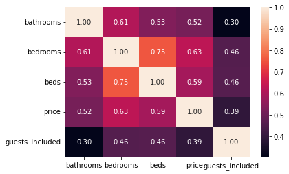

Look at the headmap above we see that some properties affected to price are bathrooms, bedrooms, beds, guests_included. The most affected propery is bedrooms.

We will check correlation between most effected property, bedrooms with price.

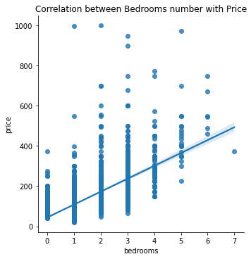

As the chart, correlation between bedrooms with prices is linear. When bedrooms increases, price increases and vice verse.

Next we will check correlations between categorical variable with price.

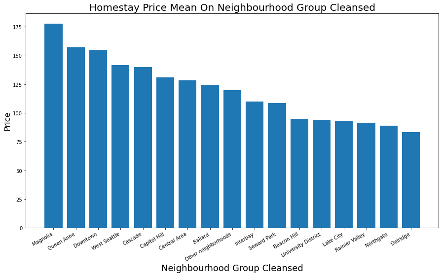

The chart show that neighbourhood group = Magnolia has highest price.

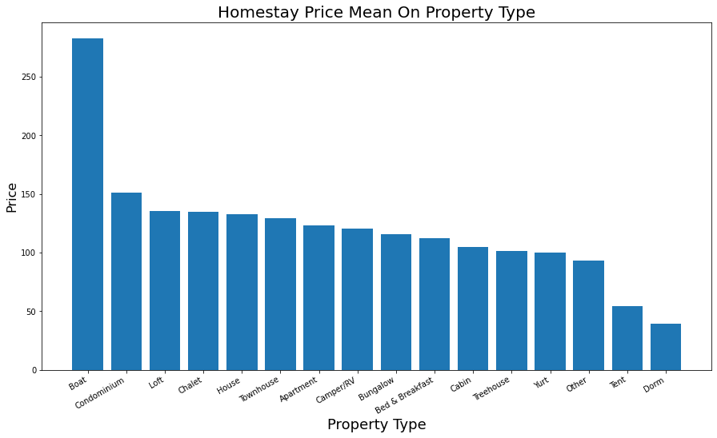

The chart show that homestay with property type = Boat has higest price.

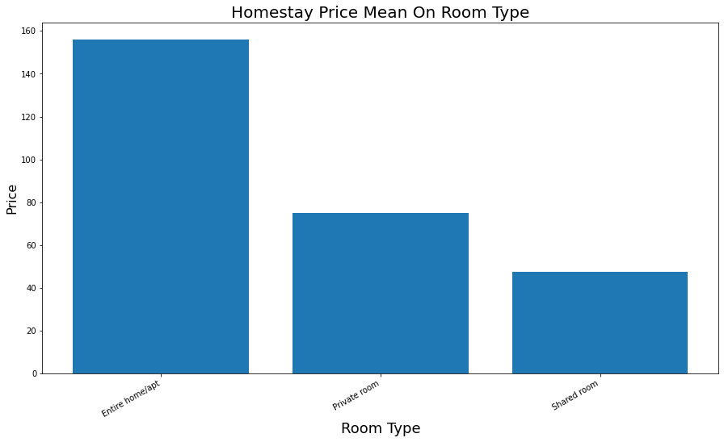

The chart show that room type = Entire home/apt has highest price.

### Conclusion:

```
Now we can conclude as following:
    - The price of homestay in Seattle are affected by properties bathrooms, bedrooms, beds, guests_included. The most affected property is bedrooms. This variable correlates with price linear. When the bedrooms increases, it will lead  to price increase.
    - Homestay have neighbourhood_group_cleansed = Magnolia has the highest price
    - Homestay have property type = boat has the highest price.
    - Homestays have room type = Entire home/apt has the highest price.
```

### Deploy

```
deploy to local server by command:
    !jupyter nbconvert seattle_airbnb.ipynb --to slides --post serve --no-input --no-prompt
```